# Premier League Model Match Prediction

Craig McGowan

04 July, 2018

## Various timelines of recent form - single measure

Using logistic regression, look at what timeline of recent goal scoring form best predicts game outcomes using leave-one-season out cross validation and evaluating models on percentage of matches accurately predicted.

| Num Matches | Logistic Train % | Logistic Test % |
| --- | --- | --- |
| 1 | 0.4665 | 0.4666 |
| 2 | 0.4773 | 0.477 |
| 3 | 0.483 | 0.484 |
| 4 | 0.4873 | 0.4875 |
| 5 | 0.4925 | 0.493 |
| 6 | 0.4935 | 0.4939 |
| 7 | 0.4983 | 0.4975 |
| 8 | 0.5011 | 0.5021 |
| 9 | 0.5045 | 0.504 |

Taking into account additional games when determining recent form improves model results, which is unsurprising. Test and training set accuracy are very similar suggesting that the models are not overfitting the data and overall accuracy is moderate, suggesting that adding additional features to the model could result in improved model performance.

## Various timelines of recent form - cumulative measures

Using logistic regression, this section evaluates what timeline of recent form best predicts results, taking into account all shorter measures of recent form. For example, the model of 5-match recent form also includes measures of 3-match and 4-match recent form.

| Num Matches | Logistic Train % | Logistic Test % |
| --- | --- | --- |
| 1 | 0.4665 | 0.4666 |
| 2 | 0.4771 | 0.477 |
| 3 | 0.4844 | 0.4837 |
| 4 | 0.4878 | 0.4857 |
| 5 | 0.4944 | 0.4921 |
| 6 | 0.4954 | 0.4923 |
| 7 | 0.499 | 0.4947 |
| 8 | 0.5026 | 0.4996 |
| 9 | 0.5047 | 0.5 |

# Recent shots

Using logistic regression, look at what timeline of recent shots attempted best predicts game outcomes using leave-one-season out cross validation and evaluating models on percentage of matches accurately predicted.

| Num Matches | Logistic Train % | Logistic Test % |
| --- | --- | --- |
| 1 | 0.4725 | 0.4712 |
| 2 | 0.4836 | 0.4838 |
| 3 | 0.4996 | 0.4982 |
| 4 | 0.5102 | 0.5095 |
| 5 | 0.5116 | 0.5101 |
| 6 | 0.5179 | 0.5148 |
| 7 | 0.5184 | 0.5168 |
| 8 | 0.5236 | 0.5215 |
| 9 | 0.5271 | 0.5248 |

## Various timelines of recent shots - cumulative measures

Using logistic regression, this section evaluates what timeline of recent shots best predicts results, taking into account all shorter measures of recent form. For example, the model of 5-match recent shots also includes measures of 3-match and 4-match recent shots.

| Num Matches | Logistic Train % | Logistic Test % |
| --- | --- | --- |
| 1 | 0.4725 | 0.4712 |
| 2 | 0.486 | 0.4847 |
| 3 | 0.5032 | 0.5001 |
| 4 | 0.5104 | 0.5082 |
| 5 | 0.5115 | 0.5089 |
| 6 | 0.5171 | 0.5141 |
| 7 | 0.5187 | 0.5141 |
| 8 | 0.5243 | 0.5194 |
| 9 | 0.5262 | 0.5202 |

# Recent shots on target

Using logistic regression, look at what timeline of recent shots on target best predicts game outcomes using leave-one-season out cross validation and evaluating models on percentage of matches accurately predicted.

| Num Matches | Logistic Train % | Logistic Test % |
| --- | --- | --- |
| 1 | 0.4764 | 0.4754 |
| 2 | 0.4885 | 0.4884 |
| 3 | 0.5013 | 0.5009 |
| 4 | 0.5089 | 0.5079 |
| 5 | 0.5094 | 0.5084 |
| 6 | 0.5125 | 0.5125 |
| 7 | 0.517 | 0.5147 |
| 8 | 0.522 | 0.5206 |
| 9 | 0.5246 | 0.5229 |

## Various timelines of recent shots on target - cumulative measures

Using logistic regression, this section evaluates what timeline of recent shots on target best predicts results, taking into account all shorter measures of recent form. For example, the model of 5-match recent shots also includes measures of 3-match and 4-match recent shots.

| Num Matches | Logistic Train % | Logistic Test % |
| --- | --- | --- |
| 1 | 0.4764 | 0.4754 |
| 2 | 0.4916 | 0.4898 |
| 3 | 0.5008 | 0.499 |
| 4 | 0.5092 | 0.5079 |
| 5 | 0.5114 | 0.5067 |
| 6 | 0.5154 | 0.5122 |
| 7 | 0.5202 | 0.5148 |
| 8 | 0.5232 | 0.52 |
| 9 | 0.5253 | 0.5204 |

# Recent corners

Using logistic regression, look at what timeline of recent corners best predicts game outcomes using leave-one-season out cross validation and evaluating models on percentage of matches accurately predicted.

| Num Matches | Logistic Train % | Logistic Test % |
| --- | --- | --- |
| 1 | 0.4663 | 0.466 |
| 2 | 0.4722 | 0.4712 |
| 3 | 0.4838 | 0.4827 |
| 4 | 0.4884 | 0.4882 |
| 5 | 0.4914 | 0.4902 |
| 6 | 0.4981 | 0.4968 |
| 7 | 0.5007 | 0.4988 |
| 8 | 0.504 | 0.504 |
| 9 | 0.5069 | 0.5058 |

## Various timelines of recent corners - cumulative measures

Using logistic regression, this section evaluates what timeline of recent shots on target best predicts results, taking into account all shorter measures of recent form. For example, the model of 5-match recent shots also includes measures of 3-match and 4-match recent shots.

| Num Matches | Logistic Train % | Logistic Test % |
| --- | --- | --- |
| 1 | 0.4663 | 0.466 |
| 2 | 0.4737 | 0.4728 |
| 3 | 0.4828 | 0.4813 |
| 4 | 0.4871 | 0.4856 |
| 5 | 0.4909 | 0.4872 |
| 6 | 0.4978 | 0.4932 |
| 7 | 0.5018 | 0.4961 |
| 8 | 0.506 | 0.4984 |
| 9 | 0.5113 | 0.5033 |

# Recent fouls

Using logistic regression, look at what timeline of recent fouls best predicts game outcomes using leave-one-season out cross validation and evaluating models on percentage of matches accurately predicted.

| Num Matches | Logistic Train % | Logistic Test % |
| --- | --- | --- |
| 1 | 0.4648 | 0.4648 |
| 2 | 0.4655 | 0.4651 |
| 3 | 0.4671 | 0.4665 |
| 4 | 0.4678 | 0.4674 |
| 5 | 0.4701 | 0.4691 |
| 6 | 0.4719 | 0.4711 |
| 7 | 0.474 | 0.4726 |
| 8 | 0.473 | 0.4737 |
| 9 | 0.4733 | 0.4733 |

## Various timelines of recent fouls - cumulative measures

Using logistic regression, this section evaluates what timeline of recent fouls best predicts results, taking into account all shorter measures of recent form. For example, the model of 5-match recent fouls also includes measures of 3-match and 4-match recent fouls

| Num Matches | Logistic Train % | Logistic Test % |
| --- | --- | --- |
| 1 | 0.4648 | 0.4648 |
| 2 | 0.4656 | 0.4647 |
| 3 | 0.4684 | 0.4667 |
| 4 | 0.4705 | 0.4689 |
| 5 | 0.4727 | 0.4696 |
| 6 | 0.4745 | 0.47 |
| 7 | 0.4759 | 0.4712 |
| 8 | 0.4773 | 0.4698 |
| 9 | 0.4777 | 0.4689 |

# Recent Offsides

Using logistic regression, look at what timeline of recent offside best predicts game outcomes using leave-one-season out cross validation and evaluating models on percentage of matches accurately predicted.

| Num Matches | Logistic Train % | Logistic Test % |
| --- | --- | --- |
| 1 | 0.4568 | 0.4554 |
| 2 | 0.4538 | 0.4552 |
| 3 | 0.4654 | 0.4511 |
| 4 | 0.4829 | 0.4488 |
| 5 | 0.4916 | 0.4444 |
| 6 | 0.488 | 0.4518 |
| 7 | 0.4966 | 0.4657 |
| 8 | 0.4931 | 0.4629 |
| 9 | 0.4999 | 0.4618 |

## Various timelines of recent offsides - cumulative measures

Using logistic regression, this section evaluates what timeline of recent offsides best predicts results, taking into account all shorter measures of recent form. For example, the model of 5-match recent offsides also includes measures of 3-match and 4-match recent offsides

| Num Matches | Logistic Train % | Logistic Test % |
| --- | --- | --- |
| 1 | 0.4568 | 0.4554 |
| 2 | 0.4846 | 0.4288 |
| 3 | 0.4727 | 0.4324 |
| 4 | 0.5021 | 0.4089 |
| 5 | 0.4977 | 0.4094 |
| 6 | 0.5149 | 0.3965 |
| 7 | 0.5439 | 0.4055 |
| 8 | 0.542 | 0.4225 |
| 9 | 0.5694 | 0.4046 |

# Recent yellow cards

Using logistic regression, look at what timeline of recent yellow cards best predicts game outcomes using leave-one-season out cross validation and evaluating models on percentage of matches accurately predicted.

| Num Matches | Logistic Train % | Logistic Test % |
| --- | --- | --- |
| 1 | 0.4653 | 0.4649 |
| 2 | 0.4657 | 0.4652 |
| 3 | 0.4692 | 0.4682 |
| 4 | 0.4725 | 0.4723 |
| 5 | 0.471 | 0.4698 |
| 6 | 0.4729 | 0.4714 |
| 7 | 0.4769 | 0.4767 |
| 8 | 0.4795 | 0.4778 |
| 9 | 0.4807 | 0.4793 |

## Various timelines of recent yellow cards - cumulative measures

Using logistic regression, this section evaluates what timeline of recent yellow cards best predicts results, taking into account all shorter measures of recent form. For example, the model of 5-match recent offsides also includes measures of 3-match and 4-match recent yellow cards.

| Num Matches | Logistic Train % | Logistic Test % |
| --- | --- | --- |
| 1 | 0.4653 | 0.4649 |
| 2 | 0.4658 | 0.4657 |
| 3 | 0.47 | 0.4689 |
| 4 | 0.4725 | 0.4698 |
| 5 | 0.473 | 0.4715 |
| 6 | 0.477 | 0.4728 |
| 7 | 0.4778 | 0.4738 |
| 8 | 0.4844 | 0.4759 |
| 9 | 0.4853 | 0.4748 |

# Plots of all measures

### Single lag models

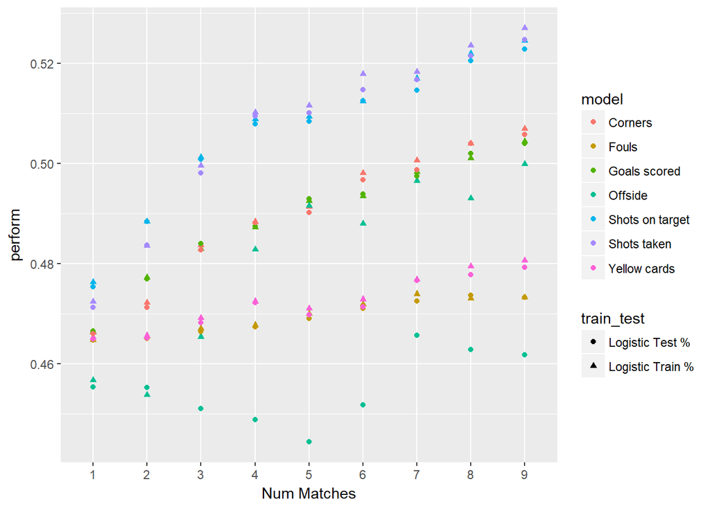

### Multiple lag models

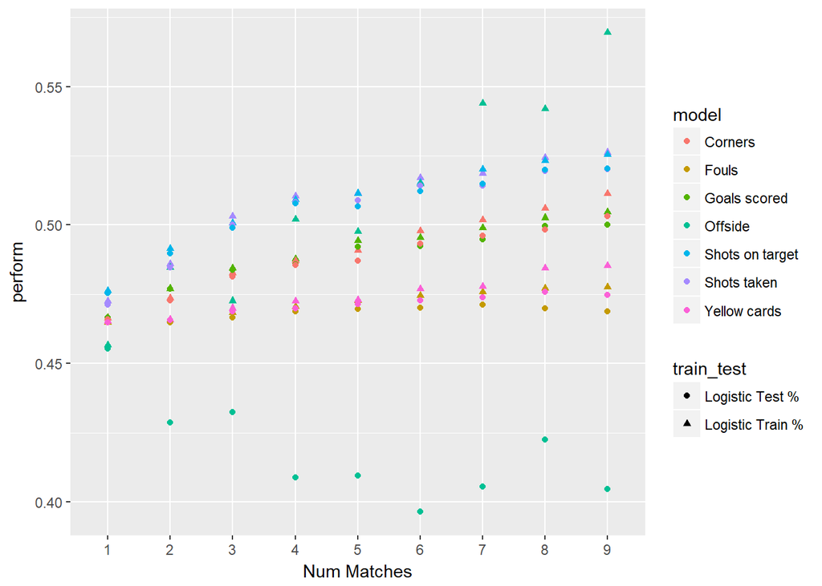